# Assignment 2 (Data frames and plotting)

## Step1: Imported the pandas library

```python
import pandas as pd
```

### Pandas version-

```python
print(pd.__version__)
```

```
1.0.5
```

## Step 2: Pandas datastructures

### Series

**Definition** Series is a fundamental datastructure in the pandas framework than holds a single array of data and an associated array of data labels called index.

Let's create a series using some dummy data-

```python
my_series = pd.Series([4.6, 2.1, -4.0, 3.0])
print(my_series)
```

```
0    4.6
1    2.1
2   -4.0
3    3.0
dtype: float64
```

Above, the left column denotes the index/data labels. While the right column denotes the data in the series. We can specify the data type while creating the series, but pandas infers the suitable data type while creating the series. For example- the datatype(dtype) of above series is float64.

We can also specifically access the index/values in a series using the following commands-

```python
print(my_series.index)
```

```
RangeIndex(start=0, stop=4, step=1)
```

```python
print(my_series.values)
```

```
[ 4.6  2.1 -4.   3. ]
```

### Data frame

Traditionally if we were to store data specific to an object, like the height and geographical location of a hill, one of the ways in python is to use a dictionary as below-

```python
scottish_hills = {'Ben Nevis': (1345, 56.79685, -5.003508),
                  'Ben Macdui': (1309, 57.070453, -3.668262),
                  'Braeriach': (1296, 57.078628, -3.728024),
                  'Cairn Toul': (1291, 57.054611, -3.71042),
                  'Sgòr an Lochain Uaine': (1258, 57.057999, -3.725416)}
```

The name of each hill is a key in this dictionary, and the data specific to each Hill is stored as values assosciated with the key.

**Data frame** in Pandas is a higher-level data structure which can be thought of as a combination of series. Let's see below how we can store the above data using a pandas data frame-

```python
df=pd.DataFrame(scottish_hills)
```

```python
print(df)
```

[output not shown]

A better way to store this data is to have a row for each hill, and let each column indicate an attribute of the hill. So, let's create a data frame to store the data this way.

```python
scottish_hills = {'Hill Name': ['Ben Nevis', 'Ben Macdui', 'Braeriach', 'Cairn Toul', 'Sgòr an Lochain Uaine'],
                  'Height': [1345, 1309, 1296, 1291, 1258],
                  'Latitude': [56.79685, 57.070453, 57.078628, 57.054611, 57.057999],
                  'Longitude': [-5.003508, -3.668262, -3.728024, -3.71042, -3.725416]}
```

```python
dataframe = pd.DataFrame(scottish_hills, columns=['Hill Name', 'Height', 'Latitude', 'Longitude'])
```

```python
dataframe
```

|  | Hill Name | Height | Latitude | Longitude |
| --- | --- | --- | --- | --- |
| 0 | Ben Nevis | 1345 | 56.796850 | -5.003508 |
| 1 | Ben Macdui | 1309 | 57.070453 | -3.668262 |
| 2 | Braeriach | 1296 | 57.078628 | -3.728024 |
| 3 | Cairn Toul | 1291 | 57.054611 | -3.710420 |
| 4 | Sgòr an Lochain Uaine | 1258 | 57.057999 | -3.725416 |

## Step 3: Accessing the data frame.

We can use the following command to access the head/top rows in a dataframe.

```python
print(dataframe.head(3))
```

```
    Hill Name  Height   Latitude  Longitude
0   Ben Nevis    1345  56.796850  -5.003508
1  Ben Macdui    1309  57.070453  -3.668262
2   Braeriach    1296  57.078628  -3.728024
```

Above we accessed the top 3 rows in the dataframe by passing the value 3 as the function argument.

Similarly, we can access the tail or last set of rows in a dataframe using the tail command.

```python
print(dataframe.tail(2))
```

```
               Hill Name  Height   Latitude  Longitude
3             Cairn Toul    1291  57.054611  -3.710420
4  Sgòr an Lochain Uaine    1258  57.057999  -3.725416
```

To access the values in a column we can use the following approach. It's similar to accessing the values associcated with a key in the dictionary.

### Columns

```python
print(dataframe['Hill Name'])
```

```
0                Ben Nevis
1               Ben Macdui
2                Braeriach
3               Cairn Toul
4    Sgòr an Lochain Uaine
Name: Hill Name, dtype: object
```

```python
print(dataframe['Height'])
```

```
0    1345
1    1309
2    1296
3    1291
4    1258
Name: Height, dtype: int64
```

To reiterate, each column represents a pandas series datastructure. So, each of the above commands returned a series. To check the data type of the result use the following command.

```python
print(type(dataframe['Height']))
```

```
<class 'pandas.core.series.Series'>
```

### Rows

We can access the rows in a dataframe using the following command-

```python
dataframe.iloc[0]
```

[output not shown]

The iloc command again returns a pandas series object containing the information of the row.

```python
type(dataframe.iloc[0])
```

```
pandas.core.series.Series
```

To access the value of a particular column in a row we can use the following command-

```python
dataframe.iloc[0,0]
```

```
'Ben Nevis'
```

A better way-

```python
dataframe.iloc[0]['Hill Name']
```

```
'Ben Nevis'
```

The columns can also be accessed in the following way-

```python
dataframe.Height
```

```
0    1345
1    1309
2    1296
3    1291
4    1258
Name: Height, dtype: int64
```

The columns can be interpreted as attributes of a data frame.

## Step 4: Filtering the data in a data frame.

The logical >,<, >=,<=,! operators can be used to filter the rows in a data frame.

```python
dataframe.Height > 1300
```

```
0     True
1     True
2    False
3    False
4    False
Name: Height, dtype: bool
```

The above statement only displays whether or not the rows statisfy the given condition which in this case is whether the height is greater than 1300.

To access the rows which statisfy the given condition we can use the following approach-

```python
dataframe[dataframe.Height > 1300]
```

[output not shown]

## Step 5: Appending data to a dataframe

To add a column to the dataframe we can use the following approach-

```python
dataframe['Region'] = ['Grampian', 'Cairngorm', 'Cairngorm', 'Cairngorm', 'Cairngorm']
```

```python
print(dataframe)
```

```
               Hill Name  Height   Latitude  Longitude     Region
0              Ben Nevis    1345  56.796850  -5.003508   Grampian
1             Ben Macdui    1309  57.070453  -3.668262  Cairngorm
2              Braeriach    1296  57.078628  -3.728024  Cairngorm
3             Cairn Toul    1291  57.054611  -3.710420  Cairngorm
4  Sgòr an Lochain Uaine    1258  57.057999  -3.725416  Cairngorm
```

To add a row we can use the following commands-

```python
row=pd.Series(["A' Bhuidheanach Bheag", 936.0, 56.870342, -4.199001, "Sample"],index=dataframe.columns)
```

```python
dataframe.append(row,ignore_index=True)
```

|  | Hill Name | Height | Latitude | Longitude | Region |
| --- | --- | --- | --- | --- | --- |
| 0 | Ben Nevis | 1345.0 | 56.796850 | -5.003508 | Grampian |
| 1 | Ben Macdui | 1309.0 | 57.070453 | -3.668262 | Cairngorm |
| 2 | Braeriach | 1296.0 | 57.078628 | -3.728024 | Cairngorm |
| 3 | Cairn Toul | 1291.0 | 57.054611 | -3.710420 | Cairngorm |
| 4 | Sgòr an Lochain Uaine | 1258.0 | 57.057999 | -3.725416 | Cairngorm |
| 5 | A' Bhuidheanach Bheag | 936.0 | 56.870342 | -4.199001 | Sample |

While using the above command it's important to note that the row is not added to the same dataframe, i.e., the original dataframe is not modified, but a new data frame is created and returned.

## Step 6: Read data from a CSV file.

To read the data from a .csv file we can use the pandas read_csv function.

```python
df=pd.read_csv('scottish_hills.csv')
```

```python
print(df.head(10))
```

```
                    Hill Name  Height   Latitude  Longitude    Osgrid
0       A' Bhuidheanach Bheag   936.0  56.870342  -4.199001  NN660775
1               A' Chailleach   997.0  57.693800  -5.128715  NH136714
2               A' Chailleach   929.2  57.109564  -4.179285  NH681041
3  A' Chraileag (A' Chralaig)  1120.0  57.184186  -5.154837  NH094147
4             A' Ghlas-bheinn   918.0  57.255090  -5.303687  NH008231
5               A' Mhaighdean   967.0  57.719644  -5.346720  NH007749
6              A' Mharconaich   973.2  56.857002  -4.290668  NN604762
7                  Am Basteir   934.0  57.247931  -6.202982  NG465253
8                   Am Bodach  1031.8  56.741727  -4.983393  NN176650
9               Am Faochagach   953.0  57.771801  -4.853899  NH303793
```

## Step 7: Sort rows in a data frame.

To sort the rows in a dataframe we can use the sort_values function. It's similar to the order_by function in SQL. We can choose the set of columns to the sort the data frame, and also choose the order of sorting- ascending or descending. In the dataframe above lets sort the rows in the decreasing order of height.

```python
sorted_hills = df.sort_values(by=['Height'], ascending=False)
```

```python
print(sorted_hills.head(5))
```

```
                       Hill Name  Height   Latitude  Longitude    Osgrid
92                     Ben Nevis  1344.5  56.796891  -5.003675  NN166712
88   Ben Macdui (Beinn Macduibh)  1309.0  57.070368  -3.669099  NN988989
104                    Braeriach  1296.0  57.078298  -3.728389  NN953999
115                   Cairn Toul  1291.0  57.054397  -3.710773  NN963972
212        Sgor an Lochain Uaine  1258.0  57.058369  -3.725797  NN954976
```

## Step 8: Import the pyplot module of matplotlib

```python
import matplotlib.pyplot as plt
```

Let's plot the heights of Scottish Hills against the latitude.

```python
x = df.Height
y = df.Latitude
```

[figure not shown]

```python
plt.scatter(x, y);
plt.xlabel('Latitute');
plt.ylabel('Height');
```

## Step 9: Linear regression and plotting

Now, let's see if we can fit the data using a linear regression model.

```python
from scipy.stats import linregress
stats = linregress(x, y)

m = stats.slope
b = stats.intercept
```

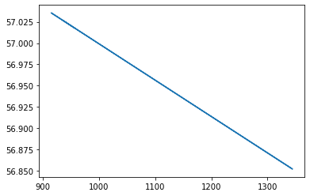

```python
plt.plot(x, m * x + b);
```

[figure not shown]

```python
plt.scatter(x, y,label='data');
plt.plot(x, m * x + b, color="red", label='model')
plt.xlabel('Latitude');
plt.ylabel('Height');
plt.legend();
```

Now, let's enhance the above plot by changing the figure size, markers and linewidth.

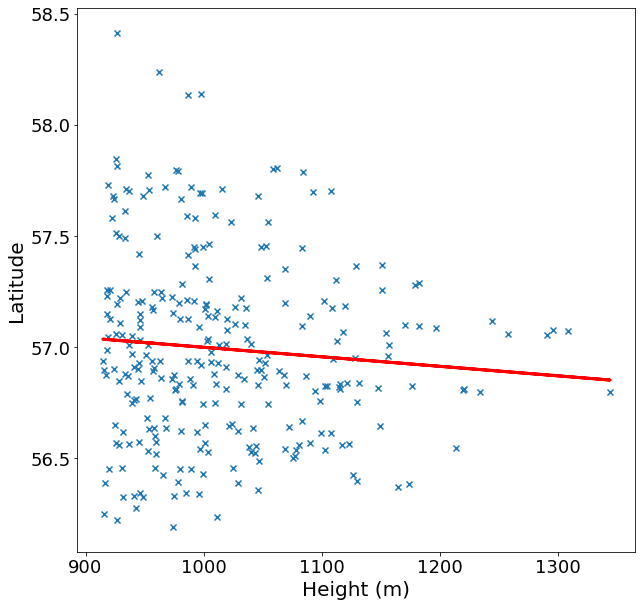

```python
plt.figure(figsize=(10,10));

plt.scatter(x, y, marker='x');

plt.plot(x, m * x + b, color="red", linewidth=3);

plt.xlabel("Height (m)", fontsize=20);
plt.ylabel("Latitude", fontsize=20);

plt.xticks(fontsize=18);
plt.yticks(fontsize=18);
```